# Regresión Dinámica

Equipo 1

5/25/2020

## Ejemplo de Modelo de Consumo acorde a variable exógena de ingresos

Este es un ejemplo de datos estacionarios donde la media y la varianza se mantienen relativamente constantes en el tiempo.

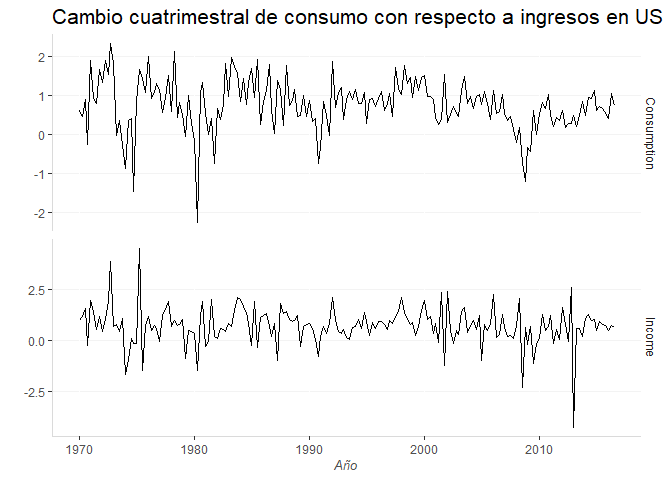

Ahora lo ajustamos a un modelo en donde no hay que especificar una diferencia en el argumento `order` puesto a que ya es estacionaria.

```
## Series: uschange[, "Consumption"]
## Regression with ARIMA(1,0,2) errors
##
## Coefficients:
##          ar1      ma1     ma2  intercept    xreg
##       0.6922  -0.5758  0.1984     0.5990  0.2028
## s.e.  0.1159   0.1301  0.0756     0.0884  0.0461
##
## sigma^2 estimated as 0.3219:  log likelihood=-156.95
## AIC=325.91   AICc=326.37   BIC=345.29
```

Tenemos un modelo definido por

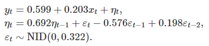

Observamos que los residuos son de ruido blanco, tal como debe cumplirse para elaborar predicciones.

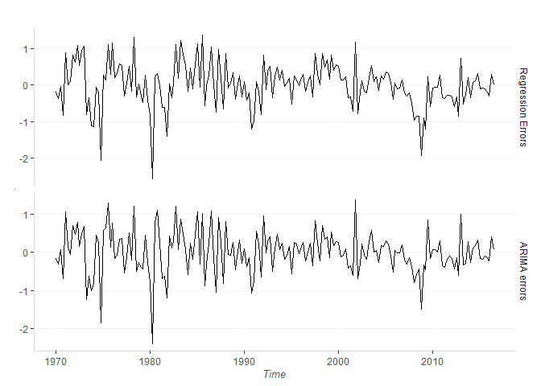

Con una vista mas detallada con grafica de autocorrelacion, probamos la aleatoriedad de los retardos.

`checkresiduals(modelo)`

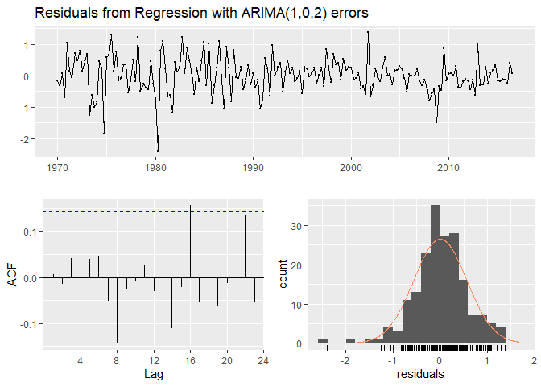

```
##
##  Ljung-Box test
##
## data:  Residuals from Regression with ARIMA(1,0,2) errors
## Q* = 5.8916, df = 3, p-value = 0.117
##
## Model df: 5.   Total lags used: 8
```

Como podemos ver se acepta la hipotesis nula por lo que si es de ruido blanco.

## Ejemplo de consumo electrico acorde a variable exogena de Temperatura ambiental máxima diaria

Inicialmente estudiamos la correlación de los datos tanto de consumo eléctrico como de temperatura.

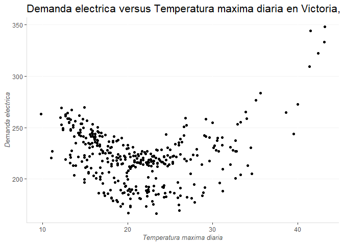

```r
elec2 <- cbind(as.data.frame(elecdaily[,"Temperature"]), as.data.frame(elecdaily[,"Demand"]))
names(elec2) <- c("Temperature", "Demand")
ggplot(elec2, aes(x = elec2$Temperature, y = elec2$Demand)) + geom_point() +
ggtitle("Demanda electrica versus Temperatura maxima diaria en Victoria, Australia 2014") +
  labs(x = "Temperatura maxima diaria", y = "Demanda electrica") +
  my_theme1
```

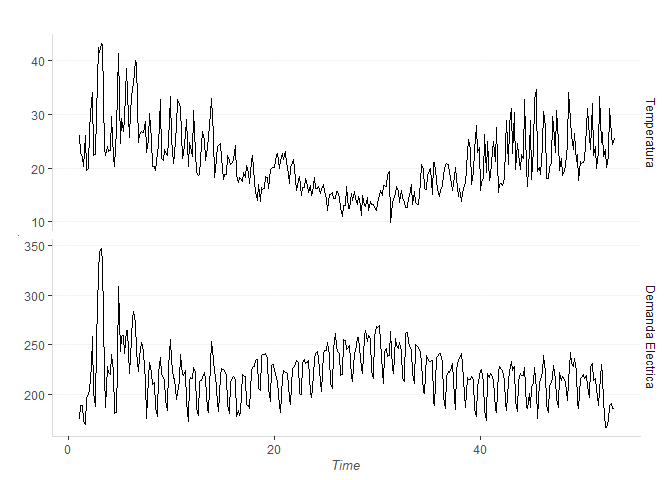

En este caso implementaremos las variables exógenas: Temperatura, Temperatura al cuadrado y Día laboral.

`checkresiduals(modelo2)`

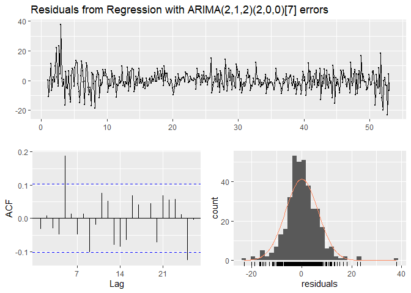

```
##
##  Ljung-Box test
##
## data:  Residuals from Regression with ARIMA(2,1,2)(2,0,0)[7] errors
## Q* = 28.229, df = 4, p-value = 1.121e-05
##
## Model df: 10.   Total lags used: 14
```

Ahora hacemos una predicción.

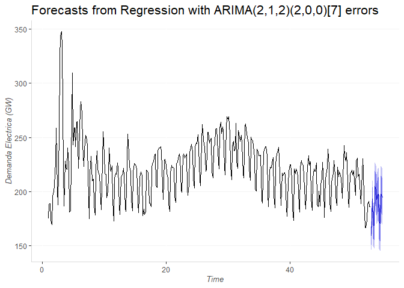

```r
fcast <- forecast(modelo2,
                  xreg = cbind(MaxTemp=rep(26,14), MaxTempSq=rep(26^2,14),
                               Workday=c(0,1,0,0,1,1,1,1,1,0,0,1,1,1)))
autoplot(fcast) + ylab("Demanda Electrica (GW)") + my_theme1
```

Ahora, ¿Cómo se apreciaría el modelo sin las variables exogenas de por medio?

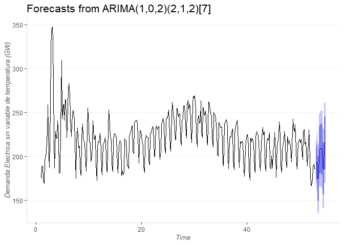

```r
modelo3 <- auto.arima(elecdaily[, "Demand"])

fcast <- forecast(modelo3)
autoplot(fcast) + ylab("Demanda Electrica sin variable de temperatura (GW)") + my_theme1
```